# Stochastic Processes

supplemental code for lecture 12

Sami Cheong

12/9/2020

### Simulation example for logistic SDE

The logistic growth moodel describe a population whose growth rate, ($r$), is regulated by a limit, known as carrying-capacity ($K$). Let $P(t)$ be the population of a community at tim e$t$. The deterministric differential equation representing this growth pattern is defined as

$$P'(t) = rP(t)(1-\frac{P(t)}{K})$$

The solution of the above ODE is:

$$P(t) = \frac{KP_0}{P_0 + (K-P_0)e^{-rt}}$$

where $r, K >0$ and $P_0 = P(0)$ is the initial distributiion of the population.

Its stochastic counterpart is defined similarly, but with the addition of a stochastic term that addresses the volatility of the growth rate. In this case, the SDE is defined (via differential form) as:

$$dP_t =rP_t(1-\frac{P_t}{K}) + \sigma P_tdB_t$$

The solution of the SDE can be simulated using the `sde` R package. The key in here is to be able to define the coefficients for `drift`, which characterizes the mean of the process, and `diffusion`, which represents its variance. In this case, the `drift` is the growth term defined by $rP_t(1-\frac{P_t}{K})$, and the `diffusion` is the noise term defined by $\sigma P_t dB_t$

Below is a sample simulation that compares different initial populatoin values and noise level.

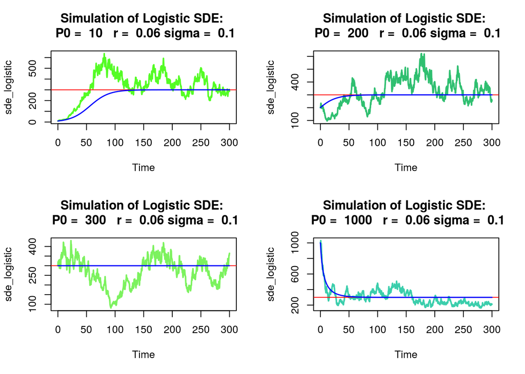

```r
# Logistic SDE
# dXt = r*Xt*(1-Xt/K)*dt + sigma*(Xt)*dBt

# define a function that plots the solution of the SDE against its deterministic counterpart

logistic_sim <- function(r,sigma,P0,K,d,s,hue){
output <-list()
t0 <- 0
tend <- 300
nsteps <- 1000
time_range <- seq(from = t0, to = tend, length.out = nsteps)
Pt <-(K*P0)/(P0+(K-P0)*exp(-r*time_range))

sde_logistic <- sde.sim(X0=P0,
                        drift=d,
                        sigma=s,
                        sigma.x = 0,
                        t0=t0,
                        T=tend,
                        N=nsteps)

plot(sde_logistic,
     main=paste("Simulation of Logistic SDE: \n P0 = ", P0, "  r = ",  r, "sigma = ", sigma),
     lwd = 2, col=randomColor(hue = hue))

abline(h=K,col='red')
lines(time_range,Pt,col='blue',lwd=1.5)


}



# define the parameters needed for the sde simulation

par(mfrow = c(2,2))

for (P0 in c(10,200,300,1000)){
  r <- 0.06
  K <- 300
  sigma <- 0.1
  d <- expression(0.06*x*(1-(x/300)) )
  s <- expression( 0.1*x )

  logistic_sim(r,sigma,P0,K,d,s,'green')


}
```

```r
par(mfrow = c(2,2))

for (P0 in c(10,200,300,1000)){
  r <- 0.06
  K <- 300
  sigma <- 0.02
  d <- expression(0.06*x*(1-(x/300)) )
  s <- expression( 0.02*x )

  logistic_sim(r,sigma,P0,K,d,s,'purple')


}
```

[figure not shown]